# Gender Equality Analysis

2017-10-31T22:42:51-05:00

# Omega Group plc- Pay Discrimination

At the last board meeting of Omega Group Plc., the headquarters of a large multinational company, the issue was raised that women were being discriminated in the company, in the sense that the salaries were not the same for male and female executives. A quick analysis of a sample of 50 employees (of which 24 men and 26 women) revealed that the average salary for men was about 8,700 higher than for women. This seemed like a considerable difference, so it was decided that a further analysis of the company salaries was warranted.

The objective is to find out whether there is indeed a significant difference between the salaries of men and women, and whether the difference is due to discrimination or whether it is based on another, possibly valid, determining factor.

## Loading the data

First, let’s load the data and have a look:

```r
omega <- read_csv(here::here("data_gender_equality", "omega.csv"))
glimpse(omega) # examine the data frame
```

```
## Rows: 50
## Columns: 3
## $ salary     <dbl> 81894, 69517, 68589, 74881, 65598, 76840, 78800, 70033, ...
## $ gender     <chr> "male", "male", "male", "male", "male", "male", "male", ...
## $ experience <dbl> 16, 25, 15, 33, 16, 19, 32, 34, 1, 44, 7, 14, 33, 19, 24...
```

```r
skim(omega)
```

Data summary

| Name | omega |
| --- | --- |
| Number of rows | 50 |
| Number of columns | 3 |
| _______________________ |  |
| Column type frequency: |  |
| character | 1 |
| numeric | 2 |
| ________________________ |  |
| Group variables | None |

**Variable type: character**

| skim_variable | n_missing | complete_rate | min | max | empty | n_unique | whitespace |
| --- | --- | --- | --- | --- | --- | --- | --- |
| gender | 0 | 1 | 4 | 6 | 0 | 2 | 0 |

**Variable type: numeric**

| skim_variable | n_missing | complete_rate | mean | sd | p0 | p25 | p50 | p75 | p100 | hist |
| --- | --- | --- | --- | --- | --- | --- | --- | --- | --- | --- |
| salary | 0 | 1 | 68717 | 8638.2 | 47033 | 63303.16 | 68847 | 74777.7 | 84576 | ▁▃▇▆▅ |
| experience | 0 | 1 | 14 | 11.9 | 0 | 2.25 | 15 | 20.8 | 44 | ▇▃▅▂▁ |

Glimpsing at the data, we notice that no values are missing and that the values for gender, salary and experience seem reasonable.

## Relationship Salary - Gender ?

The data frame `omega` contains the salaries for the sample of 50 executives in the company. Let’s find out if we can conclude that there is a significant difference between the salaries of the male and female executives.

First, let’s have a look at summary statistics, boxplots and confidence intervals:

```r
# Summary Statistics of salary by gender
mosaic::favstats(salary ~ gender, data=omega) %>%
  kbl(caption = "summary statistics on salary by gender") %>%
  kable_styling(bootstrap_options = c("striped", "hover", "condensed", "responsive")) # have a nice HTML table
```

summary statistics on salary by gender

| gender | min | Q1 | median | Q3 | max | mean | sd | n | missing |
| --- | --- | --- | --- | --- | --- | --- | --- | --- | --- |
| female | 47033 | 60338 | 64618 | 70033 | 78800 | 64543 | 7567 | 26 | 0 |
| male | 54768 | 68331 | 74675 | 78568 | 84576 | 73239 | 7463 | 24 | 0 |

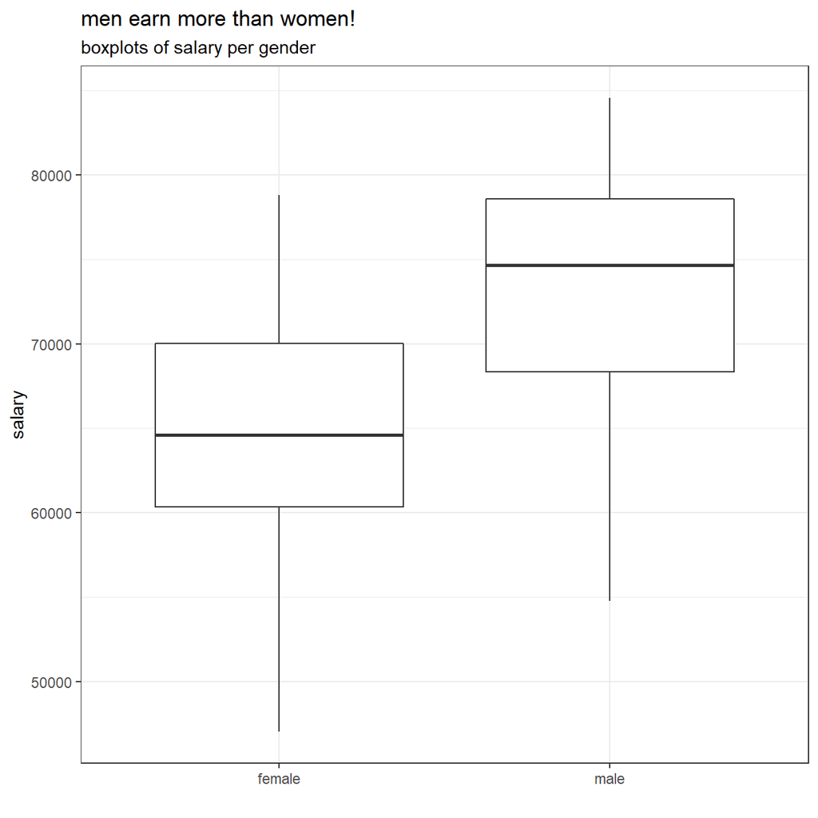

```r
# plot boxplots
omega %>%
  ggplot(aes(x = gender, y = salary)) +
  geom_boxplot() + # boxplot of salary per male/female
  labs(title = "men earn more than women!",
       subtitle = "boxplots of salary per gender",
       x = "") +
  theme_bw()
```

```r
# calculate CIs for gender male and female
CI_omega <- omega %>%
  # group by gender and calculate mean, SD, sample size, t-critical value, SE and MoE
  group_by(gender) %>%
  summarise(mean = mean(salary), # calculate average salary
            SD = sd(salary), # calculate standard deviation
            `sample size` = n(), # get the number of observations
            `t-critical value` = qt(0.975, `sample size` - 1), # get t-critical value with (`sample size`-1) degrees of freedom
            `standard error` =  SD/sqrt(`sample size`), # calculate standard error
            `margin of error` = `t-critical value` * `standard error`, # calculate margin of error
            `lower CI bound` = mean - `margin of error`, # calculate lower bound of the CI
            `upper CI bound` = mean + `margin of error`) # calculate upper bound of the CI

# print table with CIs
CI_omega %>%
  kbl(caption = "95% confidence interval on average salary") %>%
  kable_styling(bootstrap_options = c("striped", "hover", "condensed", "responsive")) # have a nice HTML table
```

95% confidence interval on average salary

| gender | mean | SD | sample size | t-critical value | standard error | margin of error | lower CI bound | upper CI bound |
| --- | --- | --- | --- | --- | --- | --- | --- | --- |
| female | 64543 | 7567 | 26 | 2.06 | 1484 | 3056 | 61486 | 67599 |
| male | 73239 | 7463 | 24 | 2.07 | 1523 | 3151 | 70088 | 76390 |

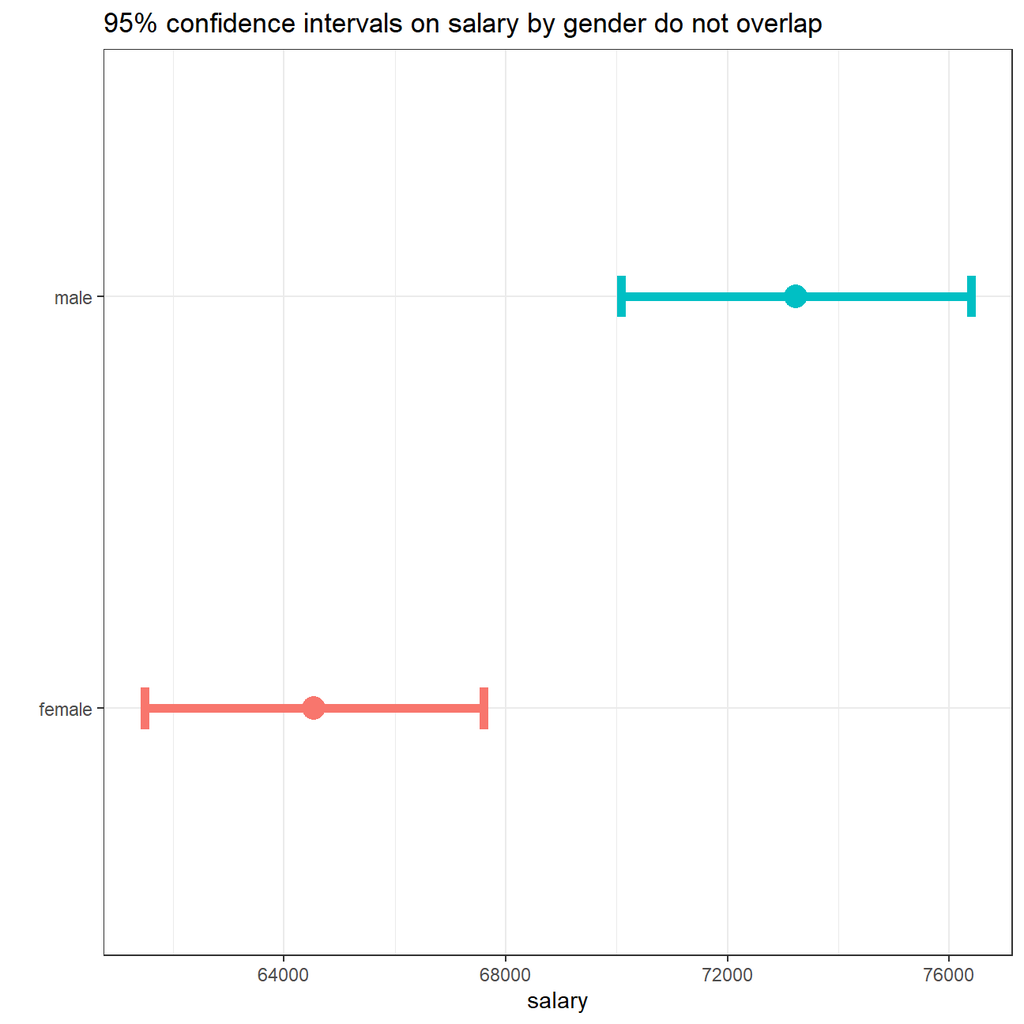

```r
# plot CIs
ggplot(CI_omega, aes(y=gender, x = mean, group = gender, color=gender)) +
  #draws the means
  geom_point(size = 5) +
  #draws the CI error bars
  geom_errorbar(aes(xmin=`lower CI bound`, xmax=`upper CI bound`), width=.1, size = 2) +
  theme_bw() +
  theme(legend.position = "none") +
  labs(title = "95% confidence intervals on salary by gender do not overlap",
       y = "",
       x = "salary")
```

As the two confidence intervals do not overlap, it seems that the difference is at least 95% statistically significant. Let us also conduct a hypothesis test.

Our hypotheses are as follows:

H0: mu_1 = mu_2, i.e. mean salaries are *not* different for men and women  
H1: mu_1 != mu_2, i.e. mean salaries *are* different for men and women

Conducting a traditional t-test yields:

```r
t.test(salary ~ gender, data = omega)
```

```
##
##  Welch Two Sample t-test
##
## data:  salary by gender
## t = -4, df = 48, p-value = 2e-04
## alternative hypothesis: true difference in means is not equal to 0
## 95 percent confidence interval:
##  -12973  -4420
## sample estimates:
## mean in group female   mean in group male
##                64543                73239
```

As a result of the traditional test, we get a test statistic with t = -4 and a p-value of close to zero. This means that under the assumption of no difference in salary means (i.e. H0), there is only a very very small probability that we would have sampled our omega dataset or a more extreme set (with an even higher difference in salary means). Hence, our data strongly implies that there is a difference in salary means! Assuming a alpha level of 5% (t has to be <= -2), we thus reject H0.

Let’s now see what the result of a simulation based test is:

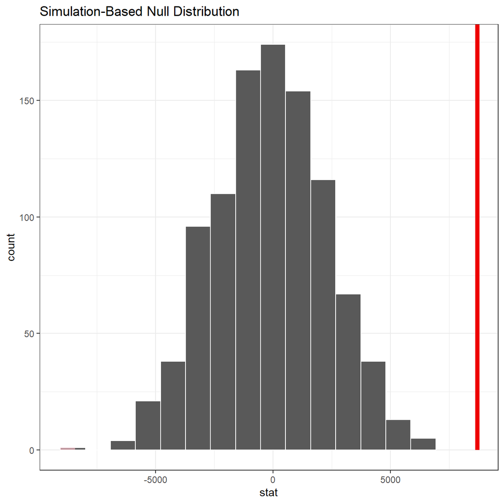

```r
# calculate actual diff in means
obs_diff <- omega %>%
  specify(salary ~ gender) %>%
  calculate(stat = "diff in means", order = c("male", "female")) # order male - female

# simulate null distribution
null_dist <- omega %>%
  specify(salary ~ gender) %>%
  # set null hypothesis (no difference between the two population means)
  hypothesize(null = "independence") %>%
  generate(reps = 1000, type = "permute") %>% # permute for hypothesis testing
  calculate(stat = "diff in means", order = c("male", "female"))

# visualise p_value and null distribution
null_dist %>% visualize() +
  shade_p_value(obs_stat = obs_diff, direction = "two-sided") +
  theme_bw()
```

```r
# print out p value
null_dist %>%
  get_p_value(obs_stat = obs_diff, direction = "two_sided") %>%
  kbl() %>%
  kable_styling(bootstrap_options = c("striped", "hover", "condensed", "responsive")) # have a nice HTML table
```

| p_value |
| --- |
| 0 |

The p-value for the simulation based test is basically the same as the one for our traditional test. Hence, the same interpretation holds true.

All in all, we can be quite certain that there really is a difference in mean salary between men and women. However, this does not mean that there is a direct causality between those two variables. It is possible that for example most women have less experience than men in this dataset, which would explain the lower average salary. Hence, it is still possible that there is no “real” gender pay gap. However, at the moment it looks like the gender pay gap is reality!

## Relationship Experience - Gender?

We want to dig deeper on the concerns we have just raised and have a look at the relationship between experience and gender.  
Indeed, the average experience of the men is approximately 21 years, whereas the women only have about 7 years experience on average:

```r
favstats (experience ~ gender, data=omega) %>%
  kbl(caption = "summary statistics on experience by gender") %>%
  kable_styling(bootstrap_options = c("striped", "hover", "condensed", "responsive")) # have a nice HTML table
```

summary statistics on experience by gender

| gender | min | Q1 | median | Q3 | max | mean | sd | n | missing |
| --- | --- | --- | --- | --- | --- | --- | --- | --- | --- |
| female | 0 | 0.25 | 3.0 | 14.0 | 29 | 7.38 | 8.51 | 26 | 0 |
| male | 1 | 15.75 | 19.5 | 31.2 | 44 | 21.12 | 10.92 | 24 | 0 |

Let’s also have a look at boxplots and confidence intervals:

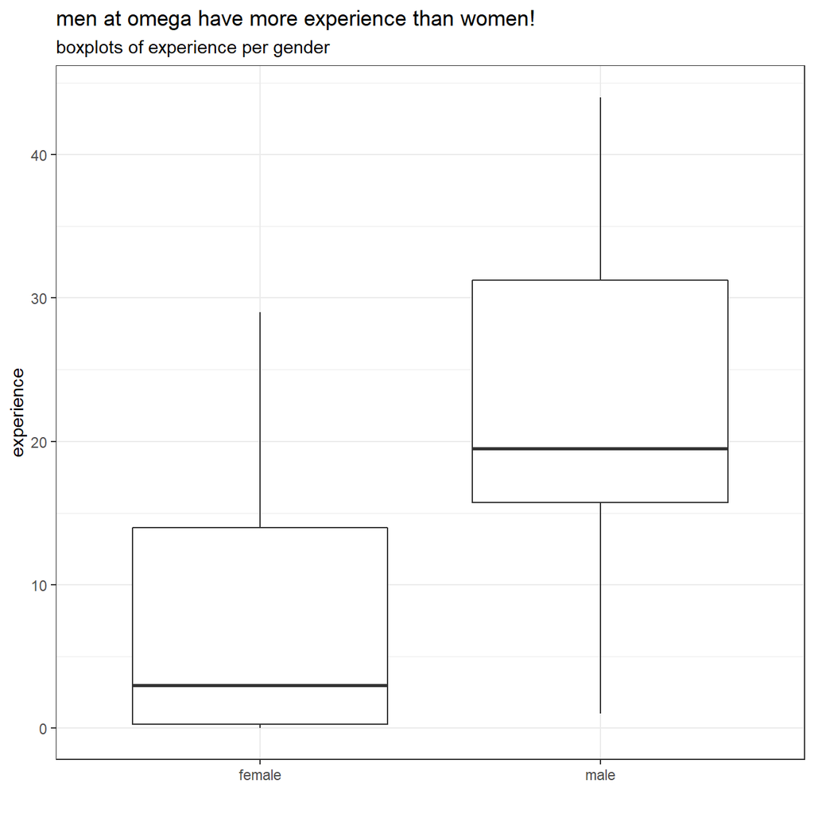

```r
# plot boxplots
omega %>%
  ggplot(aes(x = gender, y = experience)) +
  geom_boxplot() + # boxplot of experience per male/female
  labs(title = "men at omega have more experience than women!",
       subtitle = "boxplots of experience per gender",
       x = "") +
  theme_bw()
```

```r
# calculate CIs for gender male and female
CI_omega <- omega %>%
  # group by gender and calculate mean, SD, sample size, t-critical value, SE and MoE
  group_by(gender) %>%
  summarise(mean = mean(experience), # calculate average
            SD = sd(experience), # calculate standard deviation
            `sample size` = n(), # get the number of observations
            `t-critical value` = qt(0.975, `sample size` - 1), # get t-critical value with (`sample size`-1) degrees of freedom
            `standard error` =  SD/sqrt(`sample size`), # calculate standard error
            `margin of error` = `t-critical value` * `standard error`, # calculate margin of error
            `lower CI bound` = mean - `margin of error`, # calculate lower bound of the CI
            `upper CI bound` = mean + `margin of error`) # calculate upper bound of the CI

# print table with CIs
CI_omega %>%
  kbl(caption = "95% confidence intervals on average experience") %>%
  kable_styling(bootstrap_options = c("striped", "hover", "condensed", "responsive")) # have a nice HTML table
```

95% confidence intervals on average experience

| gender | mean | SD | sample size | t-critical value | standard error | margin of error | lower CI bound | upper CI bound |
| --- | --- | --- | --- | --- | --- | --- | --- | --- |
| female | 7.38 | 8.51 | 26 | 2.06 | 1.67 | 3.44 | 3.95 | 10.8 |
| male | 21.12 | 10.92 | 24 | 2.07 | 2.23 | 4.61 | 16.52 | 25.7 |

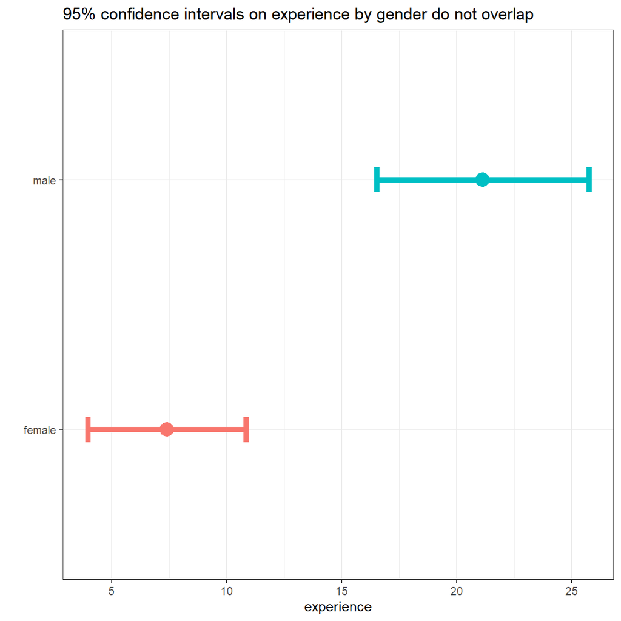

```r
# plot CIs
ggplot(CI_omega, aes(y=gender, x = mean, group = gender, color=gender)) +
  #draws the means
  geom_point(size = 5) +
  #draws the CI error bars
  geom_errorbar(aes(xmin=`lower CI bound`, xmax=`upper CI bound`), width=.1, size = 2) +
  theme_bw() +
  theme(legend.position = "none") +
  labs(title = "95% confidence intervals on experience by gender do not overlap",
       y = "",
       x = "experience")
```

As the two confidence intervals do not overlap, it seems that the difference is at least 95% statistically significant. Let us also conduct a hypothesis test.

Our hypotheses are as follows:

H0: mu_1 = mu_2, i.e. mean experiences are *not* different for men and women  
H1: mu_1 != mu_2, i.e. mean experiences *are* different for men and women

Conducting a traditional t-test yields:

```r
t.test(experience ~ gender, data = omega)
```

```
##
##  Welch Two Sample t-test
##
## data:  experience by gender
## t = -5, df = 43, p-value = 1e-05
## alternative hypothesis: true difference in means is not equal to 0
## 95 percent confidence interval:
##  -19.35  -8.13
## sample estimates:
## mean in group female   mean in group male
##                 7.38                21.12
```

As a result of the traditional test, we get a test statistic with t = -5 and a p-value of close to zero. This means that under the assumption of no difference in experience means (i.e. H0), there is only a very very small probability that we would have sampled our omega dataset or a more extreme set (with an even higher difference in experience means). Hence, our data strongly implies that there is a difference in experience means! Assuming a alpha level of 5% (t has to be <= -2), we thus reject H0.

Let’s now see what the result of a simulation based test is:

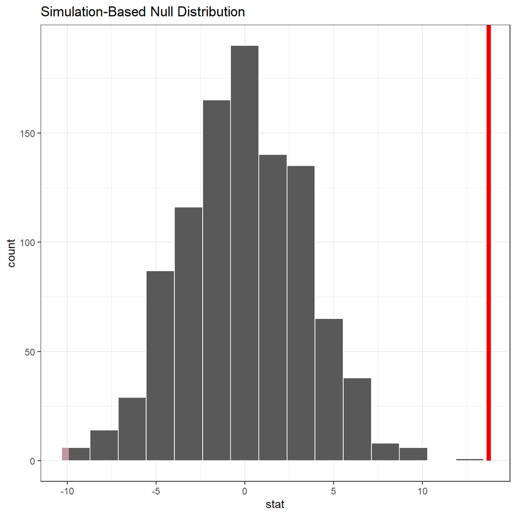

```r
# calculate actual diff in means
obs_diff <- omega %>%
  specify(experience ~ gender) %>%
  calculate(stat = "diff in means", order = c("male", "female")) # order male - female

# simulate null distribution
null_dist <- omega %>%
  specify(experience ~ gender) %>%
  # set null hypothesis (no difference between the two population means)
  hypothesize(null = "independence") %>%
  generate(reps = 1000, type = "permute") %>% # permute for hypothesis testing
  calculate(stat = "diff in means", order = c("male", "female"))

# visualise p_value and null distribution
null_dist %>% visualize() +
  shade_p_value(obs_stat = obs_diff, direction = "two-sided") +
  theme_bw()
```

```r
# print out p value
null_dist %>%
  get_p_value(obs_stat = obs_diff, direction = "two_sided") %>%
  kbl() %>%
  kable_styling(bootstrap_options = c("striped", "hover", "condensed", "responsive")) # have a nice HTML table
```

| p_value |
| --- |
| 0 |

The p-value for the simulation based test is basically the same as the one for our traditional test. Hence, the same interpretation holds true.

All in all, we can be quite certain that there really is a difference in mean experience between men and women.  
This could definitely explain why women are paid less than men!

## Relationship Salary - Experience ?

Due to our findings above, a more thorough analysis of the relationship between salary and experience is required before any conclusion can be drawn about whether there is any gender-based salary discrimination in the company.

Hence, have a look at the following graphs:

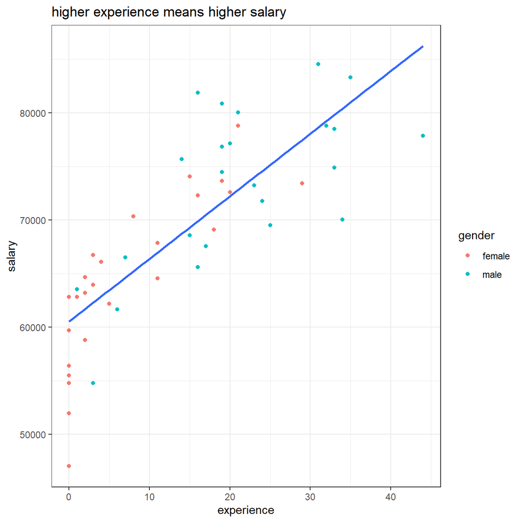

```r
ggplot(omega, aes(x = experience, y = salary)) +
  geom_point(aes(color = gender)) +
  geom_smooth(method = lm, se = FALSE) +
  theme_bw() +
  labs(title = "higher experience means higher salary")
```

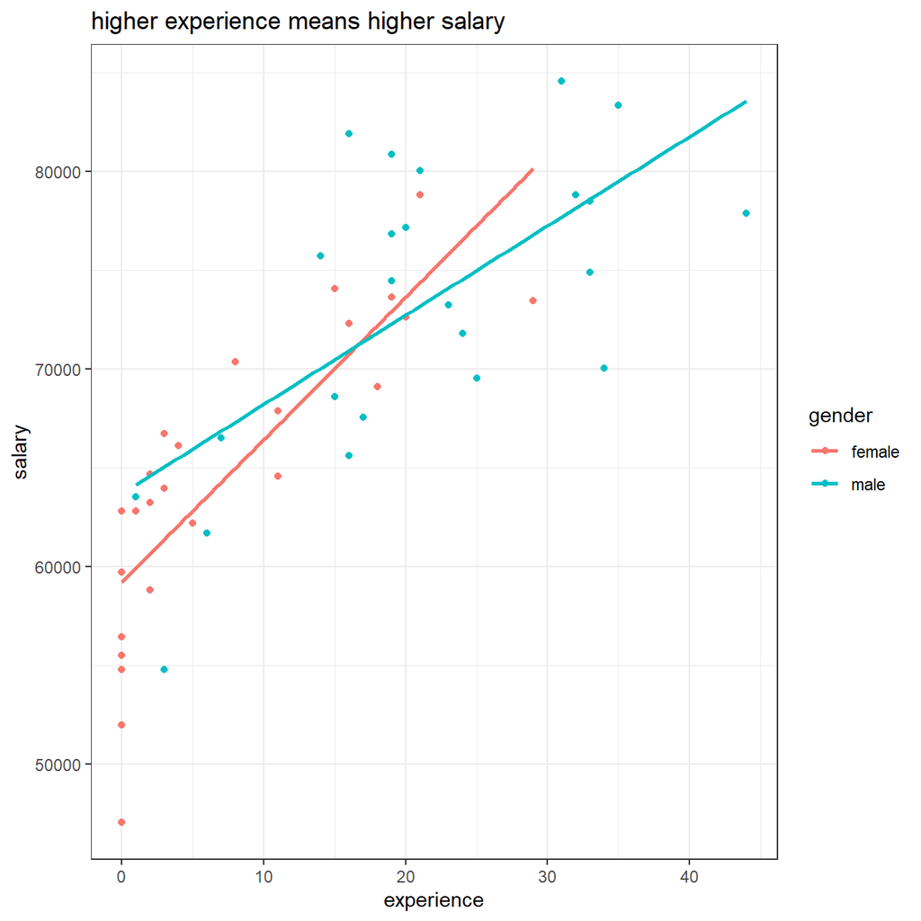

```r
ggplot(omega, aes(x = experience, y = salary, color = gender)) +
  geom_point() +
  geom_smooth(method = lm, se = FALSE) +
  theme_bw() +
  labs(title = "higher experience means higher salary")
```

This reinforces our reasoning above: Higher experience leads to a higher salary. But as the women in our dataset have overally less experience than the men, this also means that they are paid less. However, this is probably mainly due to the difference in experience.

## Check correlations between the data

Finally, let’s have a look at the following graph:

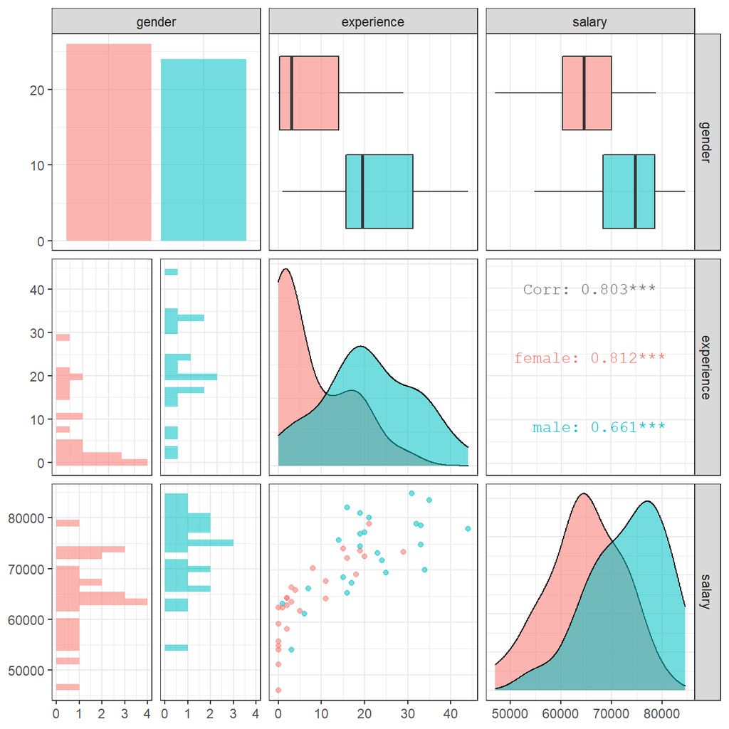

```r
omega %>%
  select(gender, experience, salary) %>% # order variables they will appear in ggpairs()
  ggpairs(aes(colour=gender, alpha = 0.3)) + # create scatterplot and correlation matrix, color by gender
  theme_bw()
```

Especially the salary vs experience scatterplot colored by gender is quite revealing: Looking only at experiences >0, we can clearly see that women are in general *not* paid less than men. The pattern between male / female is quite random, with sometimes men being paid better (given fixed experience) and sometimes women being paid better (given fixed experience). Hence, the gender pay gap seems to be disproved.  
However, there are quite some women with 0 experience. Those are also the ones that are paid least. As there are no men in our data with 0 experience, it is hard to tell if women with 0 experience are systematically discriminated.